# About me

2017-10-31T22:42:51-05:00

## Intro

Hi, I am Misha Aggarwal. I was born on 11th May, 2000 and have spent most of my time growing up in Ludhiana, biggest city of Punjab, India. Cool fact about my city is that it is known as the Manchester of India due to it’s famous appeals industry.

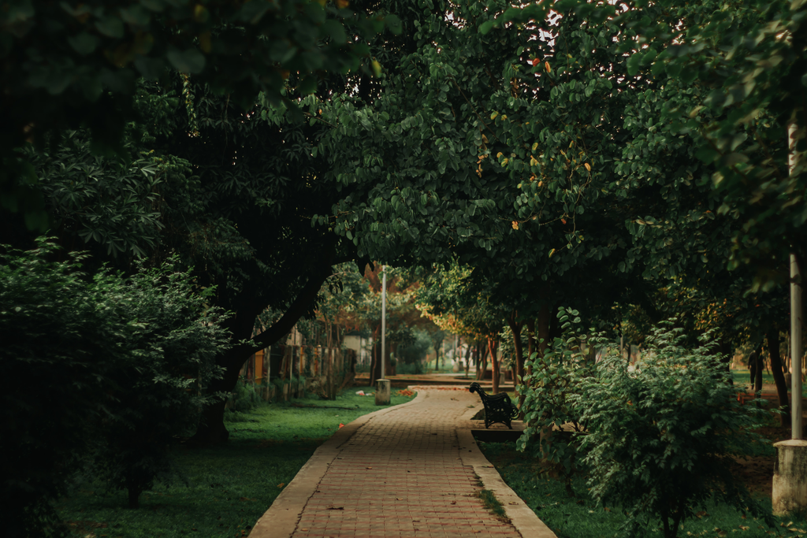

Tops things to know about me: * Love to do yoga and mediate * Visit aesthetic cafes and try different cuisines * Shopping and letting my closet overflow

I love to spend time outdoors, meet know people and rate new cafes on the basis of the quality of hot chocolate. I want explore what more the world has to offer and I am here in London to travel around UK and Europe while learning and broadening my prospective. Besides this, the cheat conversation starters with me are food or video games.

In terms of my career, I have recently completed my Bachelors of Engineering in Computer Science with my Major as Data Science. As part of my studies I took up an internship with Bain in the Consumer Products and Retail segment as a Business Analytics.

My six months tenure at Bain was primarily focused on working for two things: Capability Building project for one of the largest tea manufacturers in the world and support in piloting the 1st ever ESG promoting product in CP practices.

Now at LBS, I am reading for Masters in Analytics and Management to expose myself more towards the implementation of automation in Business world. My current goal is to learn the best of both tech and business and explore what the year at LBS holds for me!